# Lab 4: Phenological mapping and model validation

Your name

2024-02-07

### **Learning Objectives**

- Produce and interpret spatialized phenology model predictions
- Perform and interpret a model validation analysis
- Learn some basic GIS operations in R

### **Grading Rubric**

Most of your grade will be for effort - i.e., that you did your best to follow instructions and to answer questions. Each lab is worth 30 pts, so divide this number by the total number of questions to estimate the approximate number of points per question. Points may be deducted for errors in code, not following instructions, or answering questions incorrectly.

### **Instructions**

There are a set of questions associated with each exercise below that you must complete either during class or on your own time. Record answers to the questions **within** the Markdown (`.Rmd`) file and record your name on line 2. Once you’re done with the lab, knit the R markdown file as a Word document (`.docx`) within RStudio by clicking the `Knit` button found in the toolbar (look for a ball of yarn with a needle sticking out of it) and selecting `Knit to Word`. Ignore any warning messages that pop up in the Console during knitting. Submit the `.Rmd` **and** the `.docx` files on Canvas.

### **Introduction**

#### **(A) The USA National Phenology Network**

The USA National Phenology Network (USA-NPN) collects phenological observation records from volunteer and professional scientists to better understand the impact of changes in the environment on the timing of species’ life cycles. The USA-NPN also provides a number of raster-based climatological data sets and phenological models. These in-situ observation and geospatial, modeled datasets are available through a number of tools and data services. For example, the [`rnpn`](https://rdrr.io/cran/rnpn/) package provides an interface to the data and products in the USA-NPN’s database.  
Observational and gridded (raster) data can be visualized or analyzed together for a variety of purposes. In the following exercises, we will visualize and quantify the concordance between model-predicted and observed dates of lilac leaf out, which is a phenophase of lilac in which new leaves appear. A **phenophase** is an observable stage of an animal’s or plant’s life cycle that can be defined by a start and end point.

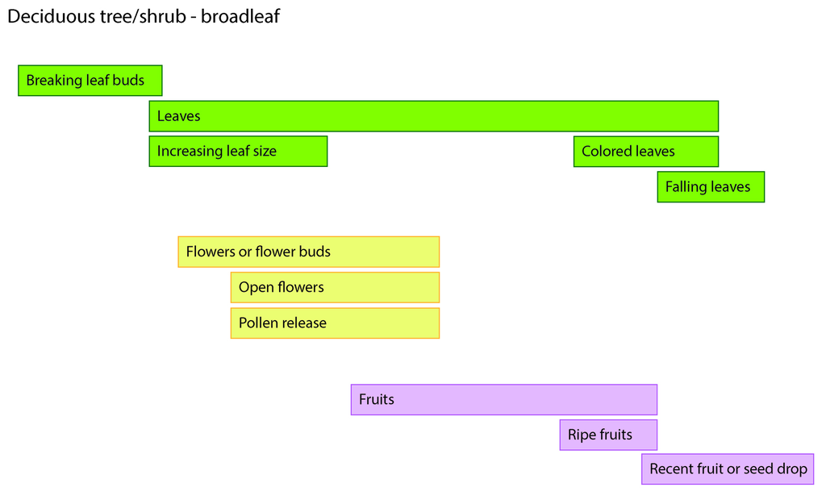

Phenophases for a deciduous tree or shrub. Source: USA National Phenology Network

Next, we will evaluate a phenology model for [bagworm](https://www.usanpn.org/data/forecasts/Bagworm) (*Thyridopteryx ephemeraeformis*) that predicts the emergence of caterpillars. Bagworm caterpillars defoliate over 50 families of evergreen and deciduous trees and shrubs, primarily arborvitae, juniper, pine, and spruce. If left untreated, these pests are capable of extensive defoliation which can cause branch dieback or death. The bagworm forecasts may help stakeholders time their treatments to target caterpillars when they are small.

#### **(B) GIS in R**

The usage of R in GIS is growing because of its enhanced capabilities for statistics, data visualization, and spatial analytics. In the following exercises, you will be introduced to some GIS operations in R using functions in the [`terra`](https://rspatial.org/pkg/) and [`sf`](https://cran.r-project.org/web/packages/sf/index.html) packages.

The `terra` package provides functions for working with raster data. A geospatial raster is any pixelated (or gridded) data where each pixel is associated with a specific geographical location. The value of a pixel can be continuous (e.g., elevation) or categorical (e.g., land use).

The `sf` package has functions for storing and working with spatial vector data. A vector uses points and line segments to identify locations on the earth whereas the raster model uses a series of cells to represent locations on the earth.

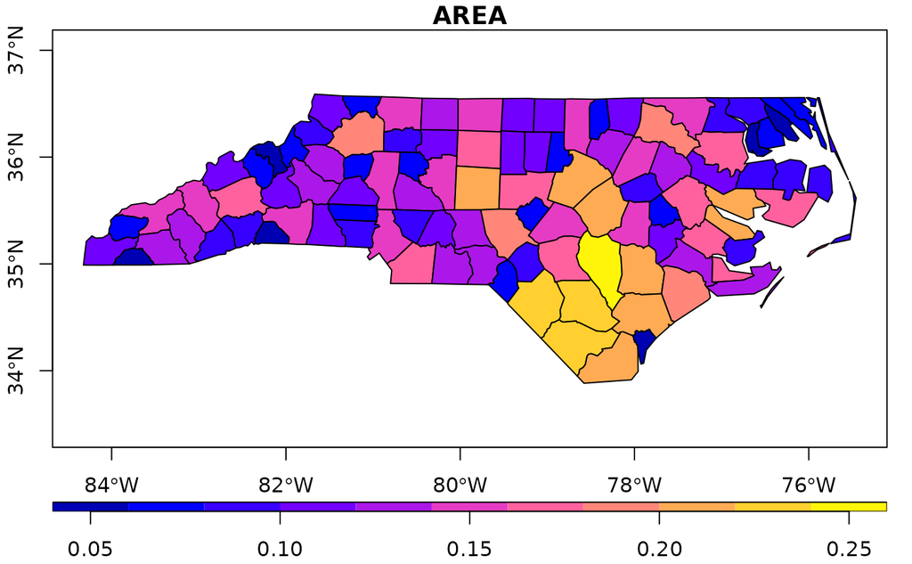

Example of a spatial feature created using the sf packages. Source: https://r-spatial.github.io/sf/articles/sf5.html

### **Exercise 1: Geospatial Lilac Leaf Out Model**

The first exercise involves visualizing and quantifying concordance between model-predicted and observed dates of lilac leaf out. Parts of this exercise are based on a [vignette](https://cran.r-project.org/web/packages/rnpn/vignettes/VII_combine_raster_point.html) for the `rnpn` package.

#### **Mapping Forecasts of Lilac Leaf Out**

We obtain raster data for model predictions of lilac leaf out for 2018 using the `npn_download_geospatial()` function in the `rnpn` package. Notice the class, dimensions, spatial resolution, geographic extent, and coordinate reference system of the raster. A coordinate reference system defines how the 2-dimensional, projected map is related to real locations on earth.

```r
# Download lilac model forecasts for 2018
lilacModel <- rast(npn_download_geospatial(
  'si-x:lilac_leaf_ncep_historic',
  '2018-01-01',
))
lilacModel
```

```
## class       : SpatRaster
## dimensions  : 1228, 2606, 1  (nrow, ncol, nlyr)
## resolution  : 0.02246419, 0.02107085  (x, y)
## extent      : -125.0208, -66.47917, 24.0625, 49.9375  (xmin, xmax, ymin, ymax)
## coord. ref. : +proj=longlat +datum=NAD83 +no_defs
## source      : file7bdc7b3819cd
## name        : file7bdc7b3819cd
```

For plotting, it’s easier to convert the raster data to a data frame. We’ll use a pipeline that converts the raster to a data frame (`as.data.frame()` function in the `terra` package), changes the name of the data column (column # 3) to `leaf_out_doy`, converts the day of year to a calendar date, and then uses the `floor_date()` function from the [`lubridate`](https://lubridate.tidyverse.org/) package to bin the dates by week of the year.

```r
# Conver raster data to a data frame and format
lilacModel_df <- lilacModel %>%
  as.data.frame(xy = TRUE) %>% # Results in a data frame
  rename("leaf_out_doy" = 3) %>% # New column name
  mutate(leaf_out_date = as.Date(leaf_out_doy, origin = "2018-01-01")) %>% # Convert day of year to calendar date
  mutate(leaf_out_week = factor(lubridate::floor_date(leaf_out_date, 'week'))) # Create bins of dates
head(lilacModel_df)
```

```
##               x        y leaf_out_doy leaf_out_date leaf_out_week
## 71692 -95.15470 49.35805          121    2018-05-02    2018-04-29
## 71693 -95.13223 49.35805          121    2018-05-02    2018-04-29
## 71694 -95.10977 49.35805          121    2018-05-02    2018-04-29
## 71695 -95.08731 49.35805          121    2018-05-02    2018-04-29
## 71696 -95.06484 49.35805          125    2018-05-06    2018-05-06
## 71697 -95.04238 49.35805          125    2018-05-06    2018-05-06
```

Notice that the data frame now has data in numerical (class `num`), date (class `Date`), and categorical (class `factor`) formats.

```r
str(lilacModel_df)
```

```
## 'data.frame':    1753552 obs. of  5 variables:
##  $ x            : num  -95.2 -95.1 -95.1 -95.1 -95.1 ...
##  $ y            : num  49.4 49.4 49.4 49.4 49.4 ...
##  $ leaf_out_doy : num  121 121 121 121 125 125 125 125 126 133 ...
##  $ leaf_out_date: Date, format: "2018-05-02" "2018-05-02" ...
##  $ leaf_out_week: Factor w/ 30 levels "2018-01-07","2018-01-14",..: 17 17 17 17 18 18 18 18 18 19 ...
```

Now let’s use `ggplot2` to visualize the predicted week of lilac leaf out for 2018 (i.e., our raster). A color paletted for weeks of the year is obtained using a custom scale function from the [`viridis`](https://cran.r-project.org/web/packages/viridis/vignettes/intro-to-viridis.html) package, `scale_fill_viridis_d()`.

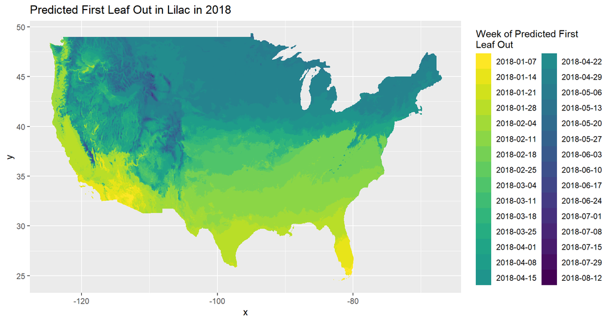

```r
# Create a map using ggplot2
ggplot() +
  geom_raster(data = lilacModel_df, aes(x = x, y = y, fill = leaf_out_week)) +
  scale_fill_viridis_d("Week of Predicted First\nLeaf Out", option = "viridis", direction = -1) +
  ggtitle("Predicted First Leaf Out in Lilac in 2018")
```

This map looks okay, but it would arguably look better without the default gray background, grid lines, and axes features. If you plan on building multiple ggplots, it’s more concise to define your theme a single time rather than repeating it each time you make a new plot.

```r
# Custom theme
my_theme <- theme(panel.grid= element_blank(),
                 panel.background = element_blank(),
                 panel.border = element_blank(),
                 axis.title = element_blank(),
                 axis.text = element_blank(),
                 axis.ticks = element_blank(),
                 title = element_text(face = "bold"),
                 legend.key.size = unit(0.4, "cm"))
```

Apply the custom theme to the plot.

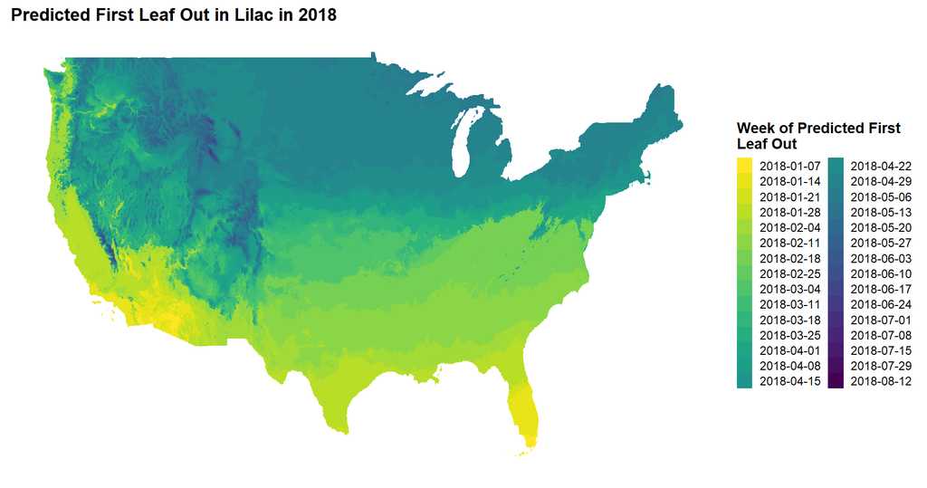

```r
# Create a map using ggplot2
ggplot() +
  geom_raster(data = lilacModel_df, aes(x = x, y = y, fill = leaf_out_week)) +
  scale_fill_viridis_d("Week of Predicted First\nLeaf Out", option = "viridis", direction = -1) +
  ggtitle("Predicted First Leaf Out in Lilac in 2018") +
  my_theme # Our custom theme
```

#### **Get State Features and Make Plots**

```r
# Create simple feature ("sf") for US states
states <- ne_states(returnclass = "sf") %>%
  filter(geonunit == "United States of America" & !name %in% c("Alaska", "Hawaii")) %>%
  st_cast("MULTILINESTRING")
```

Use `geom_sf()` to add an `sf` object to a plot - i.e., the states feature.

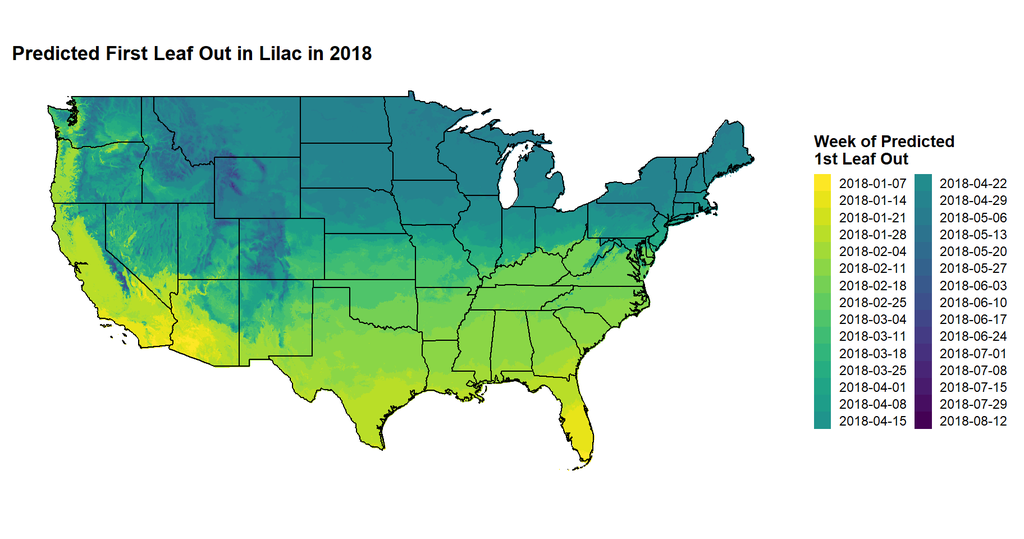

```r
# Create a map using ggplot2
ggplot() +
  geom_raster(data = lilacModel_df, aes(x = x, y = y, fill = leaf_out_week)) +
  geom_sf(data = states) +
  scale_fill_viridis_d("Week of Predicted\n1st Leaf Out", option = "viridis", direction = -1) +
  ggtitle("Predicted First Leaf Out in Lilac in 2018") +
  my_theme
```

**(1)** Explain predictions of first leaf out for lilac in the context of degree-day accumulation. For example, where in CONUS were degree-days for lilac accumulating more rapidly and how does this relate to leaf out?

*Response*:

#### **Add Phenometric Data to The Map**

How do model-predicted dates of lilac leaf out compared with observed dates? To answer this question, we import phenometric data for observed lilac leaf out dates for 2018 using the `npn_download_individual_phenometrics()` function in `rnpn`. These data were collected by volunteers and submitted to the USA-NPN’s database. The `phenophase_ids` argument is set to `373` to specify that we only want data for leaf out.

```r
# Download phenometric data
lilacObs <- npn_download_individual_phenometrics(
  request_source = 'Brittany Barker',
  years = '2018',
  species_ids = '35',
  phenophase_ids = '373'
)
```

```
##
 Found 182 records...
```

Take a look at the data dimensions. We see that there are 182 observations (rows) and 25 variables.

```r
dim(lilacObs)
```

```
## [1] 182  25
```

There are 77 unique sites in the dataset. Our goal is to add data for each of these sites to the map.

```r
length(unique(lilacObs$site_id))
```

```
## [1] 77
```

We only need data in three columns in the phenometric data: `longitude`, `latitude`, and `first_yes_doy`. The `first_yes_doy` column specifies which day of year that lilacs first had leaf out at the site. We’ll subset the columns using `select()` and take a look at the first several rows of data.

```r
lilacObs <- lilacObs %>%
  filter(state != "ON") %>% # Remove an observation from Canada
  dplyr::select("longitude", "latitude", "first_yes_doy")
```

Take a look at the first several rows of data.

```r
head(lilacObs)
```

```
##    longitude latitude first_yes_doy
## 1: -87.89300 43.09780           121
## 2: -87.89300 43.09780           121
## 3: -92.75200 36.52450            53
## 4: -83.05769 43.72269           118
## 5: -76.55337 38.88813            57
## 6: -76.55337 38.88813            57
```

To match the format of the model-predicted data, day of year is converted to a calendar date and then binned by week of the year.

```r
# Reformat lilac observation data
lilacObs2 <- lilacObs %>%
  mutate(leaf_out_date = as.Date(first_yes_doy, origin = "2018-01-01")) %>%
  mutate(leaf_out_week = factor(lubridate::floor_date(leaf_out_date, 'week')))
```

For plotting purposes, we convert the subsetted phenometric data to a simple feature (`sf`) object using the [`st_as_sf()`](https://www.rdocumentation.org/packages/sf/versions/1.0-9/topics/st_as_sf) function. We tell the function which columns contain coordinate information and specify the `crs` argument as [`4326`](https://epsg.io/4326), which corresponds to the World Geodetic System 1984 coordinate reference system.

```r
# Convert data frame to a simple feature
lilacObs_sf <- st_as_sf(lilacObs2, coords = c("longitude", "latitude"), crs = 4326)
```

Now let’s add the phenometric data so we can visualize spatial concordance between model-predicted and observed dates for first leaf out. Sites for each observation are plotted using their coordinate information and colored according to values in the `leaf_out_week` column. The map is saved to the “maps” folder for this lab.

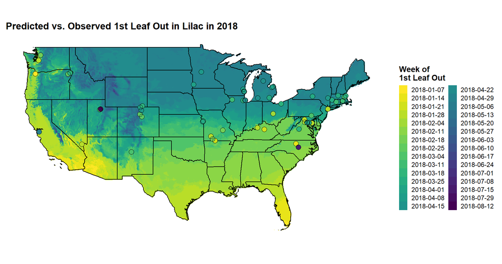

```r
# Add sites to the map
conus_map <- ggplot() +
  geom_raster(data = lilacModel_df, aes(x = x, y = y, fill = leaf_out_week)) +
  geom_sf(data = states) +
  geom_sf(data = lilacObs_sf, aes(color = leaf_out_week), size = 3, show.legend = FALSE) +
  geom_sf(data = lilacObs_sf, color = "black", size = 3, shape = 1) + # black outlines around sites
  scale_fill_viridis_d("Week of \n1st Leaf Out", option = "viridis", direction = -1) +
  scale_color_viridis_d("Week of Observed\n1st Leaf Out", option = "viridis", direction = -1) +
  ggtitle("Predicted vs. Observed 1st Leaf Out in Lilac in 2018") +
  my_theme
conus_map
```

```r
# Save the plot
ggsave(conus_map, filename = here("Lab4_phenological_mapping", "maps", "Lilac_leaf_out_2018.png"), dpi = 150, units = c('in'), width = 10, height = 6)
```

**(2)** Overall, how concordant were observed dates of first lilac leaf out with predicted dates? Comment on whether you seen a tendency of model over- or under-prediction.

*Response*:

**(3)** Where do you see strong misalignments in observed vs. predicted dates? Do you think these are misalignments due to model error or observer error? Why or why not?

*Response*:

#### **Validating Forecasts of Lilac Leaf Out**

Next, we will extract model predictions from each site and conduct a validation analysis to evaluate model performance. The first step is to create a data frame with coordinate data for the lilac leaf out observations. Next, predictions in the `lilacModel` raster are extracted using the [`extract()`](https://rdrr.io/cran/terra/man/extract.html) function in `terra`. The output is convert to a data frame and the column with predictions is renamed. Finally, we attach the results back to the lilac observation data so we have observed and predicted dates in the same data frame.

```r
# Coordinate data for observations
lilacObs_coords <- dplyr::select(lilacObs2, longitude, latitude)

# Extract model predictions and convert results to a data frame
model_extract <- terra::extract(lilacModel, lilacObs_sf, xy = TRUE) %>%
  as.data.frame() %>%
  dplyr::select("predicted_doy" = 2)

# Add results back to lilac observation data
lilacObs3 <- bind_cols(lilacObs2, model_extract)
head(lilacObs3)
```

```
##    longitude latitude first_yes_doy leaf_out_date leaf_out_week predicted_doy
## 1: -87.89300 43.09780           121    2018-05-02    2018-04-29           122
## 2: -87.89300 43.09780           121    2018-05-02    2018-04-29           122
## 3: -92.75200 36.52450            53    2018-02-23    2018-02-18            61
## 4: -83.05769 43.72269           118    2018-04-29    2018-04-29           121
## 5: -76.55337 38.88813            57    2018-02-27    2018-02-25            58
## 6: -76.55337 38.88813            57    2018-02-27    2018-02-25            58
```

An [equivalence test](https://pubmed.ncbi.nlm.nih.gov/15870057/) is one potential option for evluating predictive performance of ecological models. Here, a two one-sided (TOST) test for equivalence is used to evaluate whether predicted and observed dates (day of year) for lilac leaf out are statistically equivalent. This uses the `tost()` function in the [`equivalence`](https://cran.r-project.org/web/packages/equivalence/equivalence.pdf) R package. Statistical equivalence can be demonstrated if the two one-sided 95% confidence intervals (CIs) are completely contained within a specified equivalence interval for the difference in means (δ). We’ll define the equivalence interval as seven days (−7 < δ < 7).

```r
# Conduct a 2 one-sided TOST test (equivalence interval = 7 days)
tost_7d <- equivalence::tost(lilacObs3$predicted_doy, lilacObs3$first_yes_doy, epsilon = 7, conf.level = 0.95)
tost_7d
```

```
##
##  Welch Two Sample TOST
##
## data:  lilacObs3$predicted_doy and lilacObs3$first_yes_doy
## df = 259.41
## sample estimates:
## mean of x mean of y
##  103.1492  116.8619
##
## Epsilon: 7
## 95 percent two one-sided confidence interval (TOST interval):
##  -20.504529  -6.920885
## Null hypothesis of statistical difference is: not rejected
## TOST p-value: 0.948003
```

We can also visualize the results of the test using `ggplot` after putting them into a data frame.

```r
# Create a data frame of TOST test results
tost_7d_df <- data.frame(
  event = as.factor("First leafout"),
  days = 7,
  lower_ci = tost_7d$tost.interval[1],
  upper_ci = tost_7d$tost.interval[2],
  p_val = round(tost_7d$tost.p.value, 2),
  mean_diff = tost_7d$estimate[1] - tost_7d$estimate[2])
```

Plots the TOST test results.

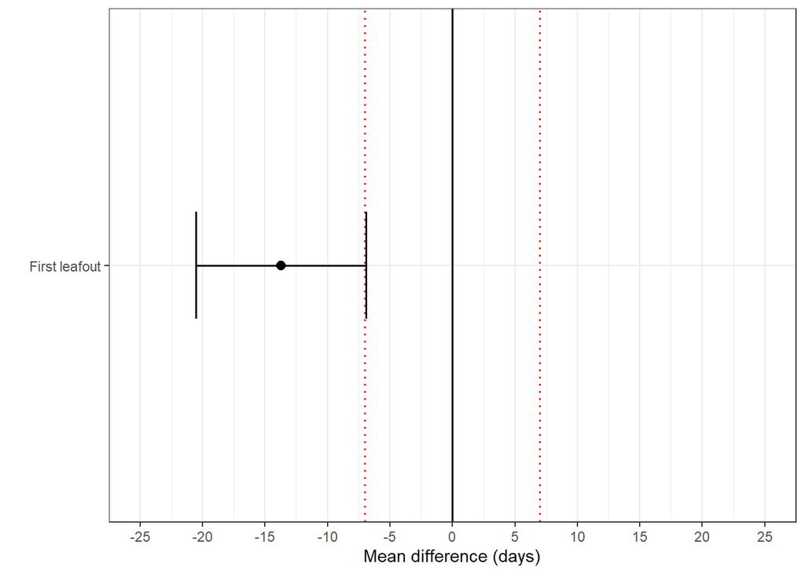

```r
ggplot(tost_7d_df) +
  # Vertical lines: 0 days vs. 7 days
  geom_vline(xintercept = 0, color = "black", size = 0.6) +
  geom_vline(xintercept = c(-7, 7), linetype = "dotted", color = "red", size = 0.6) +
  # TOST 95% confidence interval
  geom_errorbarh(aes(xmin = lower_ci, xmax = upper_ci, y = event),
                 height = .25, linewidth = 0.6) +
  # Point for mean difference
  geom_point(aes(x = mean_diff, y = event), size = 2.5) +
  scale_x_continuous(limits = c(-25,25), breaks = seq(-25, 25, 5)) +
  xlab("Mean difference (days)") +
  ylab("") +
  theme_bw()
```

**(4)** The 95% CIs for the difference between the means of predicted and observed dates (in days) for first lilac leaf out exceeded the lower equivalence bound of seven days. Describe what these results say about model under- vs. over-prediction. What would you say to someone who expects your predictions to be accurate to within 1 week?

### **Exercise 2: Model Forecast Validation for Bagworm**

Here we will use the confusion matrix approach to evaluate forecasts of the emergence of bagworm caterpillars produced by the USA-NPN. The USA-NPN’s degree-day (DD) model for bagworm (click on “Source” in the [model forecast website](https://www.usanpn.org/data/forecasts/Bagworm) uses a lower developmental threshold of 50F (10C), a start date of March 1, and the simple average method to calculate DDs.

#### **Preparing the Phenometric Data**

```r
# Bagworm data (filtered)
bagworm_df <- npn_download_status_data(
  request_source = 'Brittany Barker',
  years=c(2022),
  species_ids = c(1794)
  ) %>%
  filter(phenophase_description == "Caterpillars" & observation_date >= "2022-03-01")
```

```
##
 Found 2448 records...
```

```r
head(bagworm_df)
```

```
##    observation_id     update_datetime site_id latitude longitude
## 1:       28477719 2022-03-22 11:18:05   19935 40.41421 -76.55130
## 2:       29305215               -9999   19935 40.41421 -76.55130
## 3:       29668292 2022-04-18 10:04:12   25362 36.44083 -84.32359
## 4:       29673655 2022-04-22 10:15:20   25362 36.44083 -84.32359
## 5:       29673904 2022-04-22 10:15:20   25362 36.44083 -84.32359
## 6:       29758381 2022-07-06 12:04:21   25362 36.44083 -84.32359
##    elevation_in_meters state species_id         genus         species
## 1:                 121    PA       1794 Thyridopteryx ephemeraeformis
## 2:                 121    PA       1794 Thyridopteryx ephemeraeformis
## 3:                 383    TN       1794 Thyridopteryx ephemeraeformis
## 4:                 383    TN       1794 Thyridopteryx ephemeraeformis
## 5:                 383    TN       1794 Thyridopteryx ephemeraeformis
## 6:                 383    TN       1794 Thyridopteryx ephemeraeformis
##               common_name  kingdom individual_id phenophase_id
```

[output cut: 20 more lines]

#### **Download Model Predictions**

Next we will download DD model predictions for each location in the phenometric dataset (i.e., `bagworm_df`).

An empty data frame is created to store the results of a `for` loop that iterates over each row in the `bagworm_df` data frame and downloads the model predictions for that location. For each location, the model is run using a start date of March 1 and stops on the day when caterpillars were first observed. The last row of data is subsetted using `slice(n())` because we only want to know total DD accumulation on the observation date.

WARNING: This loop takes **several** minutes to finish!

```r
# Empty data frame to store DD accumulation (agdd) results
dd_accum_allLocs <- data.frame()

# Iterate over each row (observation) in the data frame
for (i in 1:nrow(bagworm_df)) {

  print(i)

  # Get model predictions from USA-NPN
  dd_i <- npn_get_custom_agdd_time_series(
    method = "simple", # simple average method for DD calculations
    start_date = "2022-03-01", # date to begin DD calculations
    end_date = bagworm_df$observation_date[i], # do to end DD calculations
    base_temp = 50, # lower developmental threshold
    climate_data_source = "NCEP", # climate data source
    temp_unit = "fahrenheit", # unit of temp (F vs. C)
    lat = bagworm_df$latitude[i], # latitude of location
    long = bagworm_df$longitude[i], # longitude of location
    upper_threshold = NULL) # upper threshold not used in simple average method

  # How many DDs had accumulated by the obs. date?
  dd_accum <- dd_i %>%
    slice(n()) %>% # Subset last row
    dplyr::select("dd_accum" = agdd) # Only need agdd data (DD accumulation)

  # Attach results to data frame for all results
  dd_accum_allLocs <- bind_rows(dd_accum_allLocs, dd_accum)
}
```

Add the DD accumulation data as a new column to the bagworm observation data using `bind_cols()`.

```r
# Create `dd_accum` column
bagworm_df2 <- bind_cols(bagworm_df, dd_accum_allLocs)
```

We’ll make a second subset of bagworm observation data that includes data only for dates before March 1 and assign them a DD accumulation value of `0` (`dd_accum` = `0`) because we’re assuming that no DDs accumulate before the model start date (i.e., March 1).

```r
# Get records documented prior to 3-1 and append to results
bagworm_df3 <- bagworm_df %>%
  filter(observation_date < "2022-03-01") %>%
  mutate(dd_accum = 0) %>% # assume that no DDs have accumulated
  bind_rows(bagworm_df2)
```

We create a new column called `predicted_cat` that uses a conditional statement to determine whether bagworms are in the caterpillar phenophase (`600` < DDs < `900`) according the DD model. A value of `0` for a location means that bagworm is predicted to be in a different phenophase (e.g., an adult moth if DDs > `900`). The `phenophase_status` column name is changed to `observed_cat` for clarity. Both columns are changed to type ‘factor’ (categorical data) because the confusion matrix analysis requires factors as inputs.

```r
# Add column with forecast prediction based on DD accumulation on day of observation
bagworm_df3 <- bagworm_df3 %>%
  mutate(predicted_cat = factor(ifelse(dd_accum < 600, 0,
                             ifelse(dd_accum > 900, 0, 1)), levels = c("0", "1")),
         observed_cat = factor(phenophase_status, levels = c("0", "1")))

# Compare first several rows of observed vs. predicted phenophase status
head(dplyr::select(bagworm_df3, site_id, observed_cat, predicted_cat))
```

```
##    site_id observed_cat predicted_cat
## 1:   19935            0             0
## 2:   19935            0             0
## 3:   25362            0             0
## 4:   25362            0             0
## 5:   25362            0             0
## 6:   25362            0             0
```

#### **Calculate a Confusion Matrix**

Finally, we will statistically compare observed vs. model-predicted phenophase (`0` = not caterpillars, `1` = caterpillars) using a confusion matrix. A [confusion matrix](https://www.dataschool.io/simple-guide-to-confusion-matrix-terminology/) is a special kind of contingency table with two dimensions (“actual” and “predicted”), and identical sets of “classes” in both dimensions. Each combination of dimension and class is a variable in the contingency table.

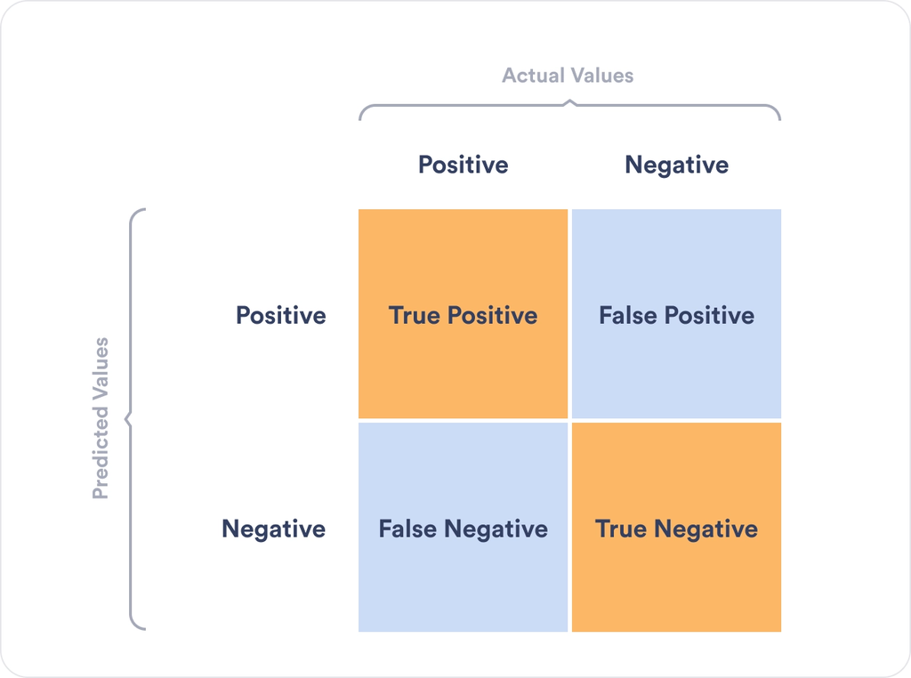

Source: https://plat.ai/blog/confusion-matrix-in-machine-learning/

The confusion matrix for bagworm is computed using the `confusionMatrix()` function of the [`caret`](https://topepo.github.io/caret/) package, where the inputs are observed vs. predicted caterpillars.

```r
# Column type must be factor for confusion matrix calculation
confusionMatrix(bagworm_df3$observed_cat, bagworm_df3$predicted_cat)
```

```
## Confusion Matrix and Statistics
##
##           Reference
## Prediction   0   1
##          0 247  16
##          1   0   0
##
##                Accuracy : 0.9392
##                  95% CI : (0.9031, 0.9648)
##     No Information Rate : 0.9392
##     P-Value [Acc > NIR] : 0.5659950
##
##                   Kappa : 0
##
##  Mcnemar's Test P-Value : 0.0001768
##
##             Sensitivity : 1.0000
##             Specificity : 0.0000
##          Pos Pred Value : 0.9392
##          Neg Pred Value :    NaN
##              Prevalence : 0.9392
##          Detection Rate : 0.9392
##    Detection Prevalence : 1.0000
##       Balanced Accuracy : 0.5000
##
##        'Positive' Class : 0
##
```

**(5)** Interpret the confusion matrix results, paying attention to what they say about potential model under- or over-prediction.

**(6)** Which values in the matrix represent the omission vs. commission errors? What are the consequences (if any) of these errors for bagworm management?

**(7)** In the code chunk below, create a plot that depicts the locations where bagworm caterpillar observations were collected. To do this, you’ll need to convert the `bagworm_df3` data frame to an `sf` object (use `4326` for the “crs” argument) and then use `geom_sf` in the `ggplot` function to plot the locations. Copy and paste `ggplot` code from Exercise 1 to make things easier. You can give your plot an informative title.

**(8)** According to your map, how many locations were the bagworm caterpillar observations derived from and where are they located?

*Response*:

**(9)** Do the number and spatial distribution of the locations affect your confidence in results of the confusion matrix (i.e., how much we can rely on the results as a form of model validation)? Why or why not?

*Response*:

**(10)** Discuss your overall results from this lab exercise, particularly regarding the importance of evaluating model performance using ground-based data.

*Response*: